# Building the Model and Running Time Series

Model (finish later when you’re bored)
$$\begin{align}
\newline
\frac{d A}{dt} &= i - A(d_A + \gamma_I F_I + \gamma_U F_U \\
\newline
\frac{d P}{dt} &= r_P D_I - P(d_P + \beta_I F_I + \beta_U F_U) \\
\newline
\frac{d F_U}{dt} &= F_U (\gamma_U e_{FU}A - d_{FU}) -P\beta_I F_U + F_I(\gamma_I e_{FI}A) \\
\newline
\frac{d F_I}{dt} &= P\beta_I F_U - d_{FI}F_I \\
\newline
\frac{d S_U}{dt} &= r_{SU}S_U - (D_U e_{DU} S_U \alpha_{DUSU} + D_Ie_{DI}S_U \alpha_{DISU}) + r_{SI}S_I - F_I S_U c\\
\newline
\frac{d S_I}{dt} &= F_I S_U c - (D_U e_{DU}\alpha_{DUSI} + D_Ie_{DI}\alpha_{DISI})\\
\newline
\frac{d D_U}{dt} &= D_U(S_U e_{DU} \alpha_{DUSU} - d_{DU} - S_I e_{DU} \alpha_{DUSI}) + D_I(S_U e_{DISU} + S_I e_{DI} \alpha_{DISI})\\
\newline
\frac{d D_I}{dt} &= D_i S_I e_{DU} \alpha_{DUSI} - d_{DI}\\
\end{align}$$

Picking Parameters - the following are parameters from Long et al

```r
source("build_paramvals.R") # continually edited as chunks of the model are added
# should I also make a file for initial state variable values?
## yes
source("build_statevars0.R")
tset <- seq(from=0, to=400, length.out = 5000) # definitely going to have to tweak time scale later
# color for algae
Acol <- "green"
# color for 1IH snails
Fcol <- "orange"
# color for 2IH fish
Scol <- "purple"
# color for DH birbs
Dcol <- "blue"
# color for parasite eggs
Pcol <- "red"
```

## One For-Loop at a time

### Let’s Start with algae

$$\begin{align}
\newline
\frac{d A}{dt} &= i - A(d_A + \gamma_I F_I + \gamma_U F_U) \\
\end{align}$$

[figure not shown]

```r
# initial values for FI and FU are zero
F_I <- 0
F_U <- 0
# set up empty vectors for algae A
A.simu <- NaN*tset; A.simu[1] <- A0
# for loop
for(i in 2:length(tset)){
    dt <- tset[i]-tset[i-1]
    A <- A.simu[i-1]
    dA <- (inp - A*(d_A + gamma_I*F_I + gamma_U*F_U))*dt
    A.simu[i] <- A + dA
}
# plot
plot(tset, A.simu,type='l',las=1,lwd=2,ylab='Population Size',xlab='Time', col=Acol,ylim=c(0,100))
legend(x=70,y=90,legend=c('Algae'),lwd=2,col=c(Acol))
```

ok, that worked, algae is just growing logistically somehow… due to death?

### Now lets add in first intermediate hosts (snails) but without parasites in the system

We should see consumption of algae and growth of snails (I didnt set this up to have a carrying capacity or predator but I probably should…)
$$\begin{align}
\newline
\frac{d F_U}{dt} &= F_U (\gamma_U e_{FU}A - d_{FU}) -P\beta_I F_U + F_I(\gamma_I e_{FI}A) \\
\newline
\frac{d F_I}{dt} &= P\beta_I F_U - d_{FI}F_I \\
\end{align}$$

```r
# we're not adding in parasites yet so
P <- 0
# set up empty vectors and initial values
A.simu <- NaN*tset; A.simu[1] <- A0
FI.simu <- NaN*tset; FI.simu[1] <- 0 # no parasites yet so this is 0
FU.simu <- NaN*tset; FU.simu[1] <- F_U0
# for loop
for(i in 2:length(tset)){
    dt <- tset[i]-tset[i-1]
    A <- A.simu[i-1]
    F_U <- FU.simu[i-1]
    F_I <- FI.simu[i-1]
    dA <- (inp - A*(d_A + gamma_I*F_I + gamma_U*F_U))*dt
    dF_U <- (F_U*(gamma_U*e_FU*A - d_FU)  # grazing * conversion efficiency * algae pop - death
             - (P*beta_I*F_U)             # parasites (0) * infection * uninfected pop, should = 0
             + F_I*(gamma_I*e_FI*A))*dt   # births from infecteds, should = 0

    # right now this is causing insane rapid pred prey cycles late in the game
    dF_I <- ((P*beta_I*F_U) - (d_FI*F_I))*dt
    A.simu[i] <- A + dA
    FU.simu[i] <- F_U + dF_U
    FI.simu[i] <- F_I + dF_I
}
# plot
plot(tset, A.simu,type='l',las=1,lwd=2,ylab='Population Size',xlab='Time', col=Acol,ylim=c(0,20))
lines(tset, FU.simu, type = 'l', las = 1, lwd = 2, col = Fcol)
```

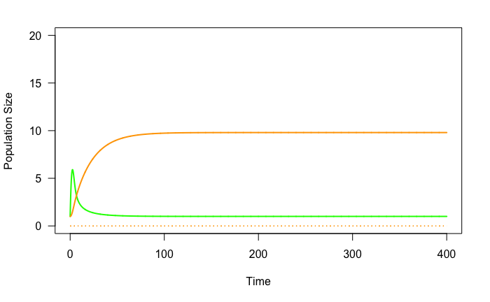

```r
lines(tset, FI.simu, type = 'l', las = 1, lty = 3, col = Fcol)
legend(x=70,y=90,legend=c('Algae', '1st Intermediate Host'),lwd=2,col=c(Acol, Fcol))
```

### Let’s add second intermediate hosts

We should see fish coming out of nowhere (might need to fix this) and not being eaten yet so they’re gonna explode, snails are still not being eaten or infected so they will also explode, and algae should stay the same. not much should change
$$\begin{align}
\frac{d S_U}{dt} &= r_{SU}S_U - (D_U e_{DU} S_U \alpha_{DUSU} + D_Ie_{DI}S_U \alpha_{DISU}) + r_{SI}S_I - F_I S_U c\\
\newline
\frac{d S_I}{dt} &= F_I S_U c - (D_U e_{DU}\alpha_{DUSI} + D_Ie_{DI}\alpha_{DISI})\\
\newline
\end{align}$$

```r
# we're not adding in parasites yet so
P <- 0
c <- 0
# no predators yet either so
D_U <- 0
D_I <- 0
# set up empty vectors for algae A
A.simu <- NaN*tset; A.simu[1] <- A0
FI.simu <- NaN*tset; FI.simu[1] <- 0 # no parasites yet so this is 0
FU.simu <- NaN*tset; FU.simu[1] <- F_U0
SI.simu <- NaN*tset; SI.simu[1] <- 0 # no parasites yet so this is 0
SU.simu <- NaN*tset; SU.simu[1] <- S_U0
# for loop
for(i in 2:length(tset)){
    dt <- tset[i]-tset[i-1]
    A <- A.simu[i-1]
    F_U <- FU.simu[i-1]
    F_I <- FI.simu[i-1]
    S_U <- SU.simu[i-1]
    S_I <- SI.simu[i-1]
    # algae
    dA <- (inp - A*(d_A + gamma_I*F_I + gamma_U*F_U))*dt
    # uninfected 1IH
        # right now this is causing insane rapid pred prey cycles late in the game
    dF_U <- (F_U*(gamma_U*e_FU*A - d_FU)  # grazing * conversion efficiency * algae pop - death
             - (P*beta_I*F_U)             # parasites (0) * infection * uninfected pop, should = 0
             + F_I*(gamma_I*e_FI*A))*dt   # births from infecteds, should = 0
    # infected 1IH
    # this should stay zero
    dF_I <- ((P*beta_I*F_U)
             - (d_FI*F_I))*dt
    # uninfected 2IH
    dS_U <- ((r_SU*S_U)                                              # births
             - (D_U * e_DU * alpha_DUSU + D_I*e_DI*S_U*alpha_DISU)   # consumption by uninfected and infected predators, no natural mortality
             + r_SI * S_I                                            # births of infecteds, should = 0
             - F_I * S_U * c)* dt                                    # loss due to movement to infected class
    # infected 2IH
      # should stay zero
    dS_I <- ((F_I * S_U * c) -                                          # infection
               (D_U * e_DU * alpha_DUSI + D_I * e_DI * alpha_DISI))*dt  # consumption by uninfected and infected predators

    A.simu[i] <- A + dA
    FU.simu[i] <- F_U + dF_U
    FI.simu[i] <- F_I + dF_I
    SU.simu[i] <- S_U + dS_U
    SI.simu[i] <- S_I + dS_I
}
# plot
plot(tset, A.simu,type='l',las=1,lwd=2,ylab='Population Size',xlab='Time', col=Acol,ylim=c(-0,100))
lines(tset, FU.simu, type = 'l', las = 1, lwd = 2, col = Fcol)
```

```r
lines(tset, FI.simu, type = 'l', las = 1, lty = 3, col = Fcol)
lines(tset, SU.simu, type = 'l', las = 1, lwd = 2, col = Scol)
```

[figure not shown]

```r
lines(tset, SI.simu, type = 'l', las = 1, lty = 3, col = Scol)
legend(x=70,y=90,legend=c('Algae', '1st Intermediate Host'),lwd=2,col=c(Acol, Fcol))
```

OK, insane exponential growth of 2IH/fish, looks crazy… but prob accurate since no natural mortality

### Let’s add in definitive hosts, birds

This should start to make things interesting, at least for fish 2IHs I should expect to see a typical type 1 functional response to prey from pred
$$\begin{align}
\frac{d D_U}{dt} &= D_U(S_U e_{DU} \alpha_{DUSU} - d_{DU} - S_I e_{DU} \alpha_{DUSI}) + D_I(S_U e_{DISU} + S_I e_{DI} \alpha_{DISI})\\
\newline
\frac{d D_I}{dt} &= D_i S_I e_{DU} \alpha_{DUSI} - d_{DI}\\
\end{align}$$

```r
# we're not adding in parasites yet so
P <- 0
c <- 0
r_SI <- 0 # infected reproductive rate is zero
# set up empty vectors and initial values
A.simu <- NaN*tset; A.simu[1] <- 1
FI.simu <- NaN*tset; FI.simu[1] <- 0 # no parasites yet so this is 0
FU.simu <- NaN*tset; FU.simu[1] <- 1
SI.simu <- NaN*tset; SI.simu[1] <- 0 # no parasites yet so this is 0
SU.simu <- NaN*tset; SU.simu[1] <- 1
DI.simu <- NaN*tset; DI.simu[1] <- 0 # no parasites yet so this is 0
DU.simu <- NaN*tset; DU.simu[1] <- 1
# for loop
for(i in 2:length(tset)){
    dt <- tset[i]-tset[i-1]
    A <- A.simu[i-1]
    F_U <- FU.simu[i-1]
    F_I <- FI.simu[i-1]
    S_U <- SU.simu[i-1]
    S_I <- SI.simu[i-1]
    D_U <- DU.simu[i-1]
    D_I <- DI.simu[i-1]
    # algae
    dA <- (inp - A*(d_A + gamma_I*F_I + gamma_U*F_U))*dt
    # uninfected 1IH
    dF_U <- (F_U*(gamma_U*e_FU*A - d_FU)  # grazing * conversion efficiency * algae pop - death
             - (P*beta_I*F_U)             # parasites (0) * infection * uninfected pop, should = 0
             + F_I*(gamma_I*e_FI*A))*dt   # births from infecteds, should = 0
    # infected 1IH
    # this should stay zero
    dF_I <- ((P*beta_I*F_U)
             - (d_FI*F_I))*dt
    # uninfected 2IH
    dS_U <- ((r_SU*S_U)                                              # births
             - S_U*(D_U * e_DU * alpha_DUSU + D_I*e_DI*alpha_DISU)   # consumption by uninfected and infected predators
             + (r_SI * S_I)                                            # births of infecteds, should = 0 because SI is 0
             - (F_I * S_U * c))* dt                                    # loss due to movement to infected class
    # infected 2IH
      # should stay zero
    dS_I <- ((F_I * S_U * c) -                                          # infection
               S_I*(D_U * e_DU * alpha_DUSI + D_I * e_DI * alpha_DISI))*dt  # consumption by uninfected and infected predators

    # uninfected DH
    dD_U <- (D_U *((S_U * e_DU * alpha_DUSU) - d_DU - (S_I * e_DU * alpha_DUSI)) # births - death - infection
             + D_I*((S_U * e_DI * alpha_DISU) + (S_I * e_DI * alpha_DISI)))* dt  # births by infected class

    # infected DH
      # should stay zero
    dD_I <- (D_I *((S_I * e_DU * alpha_DUSI) - d_DI))* dt  # new infections from eating infected 2IH - death (not sure how conversion rate fits in here -- maybe should be mass action w/o e)
    A.simu[i] <- A + dA
    FU.simu[i] <- F_U + dF_U
    FI.simu[i] <- F_I + dF_I
    SU.simu[i] <- S_U + dS_U
    SI.simu[i] <- S_I + dS_I
    DU.simu[i] <- D_U + dD_U
    DI.simu[i] <- D_I + dD_I
}
# plot
plot(tset, A.simu,type='l',las=1,lwd=2,ylab='Population Size',xlab='Time', col=Acol,ylim=c(0,10), xlim = c(0, 400))
lines(tset, FU.simu, type = 'l', las = 1, lwd = 2, col = Fcol)
```

```r
lines(tset, FI.simu, type = 'l', las = 1, lty = 3, col = Fcol)
lines(tset, SU.simu, type = 'l', las = 1, lwd = 2, col = Scol)
```

```r
lines(tset, SI.simu, type = 'l', las = 1, lty = 3, col = Scol)
lines(tset, DU.simu, type = 'l', las = 1, lwd = 2, col = Dcol)
```

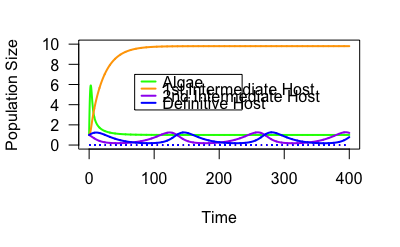

```r
lines(tset, DI.simu, type = 'l', las = 1, lty = 3, col = Dcol)
legend(x=70,y=7,legend=c('Algae', '1st Intermediate Host','2nd Intermediate Host','Definitive Host'),lwd=2,col=c(Acol, Fcol,Scol,Dcol))
```

Looks ok, populations are really small, will deal with that later

### NOW LETS ADD PARASITES

$$\begin{align}
\newline
\frac{d P}{dt} &= r_P D_I - P(d_P + \beta_I F_I + \beta_U F_U) \\
\end{align}$$

```r
# set up empty vectors and initial values
A.simu <- NaN*tset; A.simu[1] <- 1
FI.simu <- NaN*tset; FI.simu[1] <- 0 # lets see what happens if this starts at zero
FU.simu <- NaN*tset; FU.simu[1] <- 1
SI.simu <- NaN*tset; SI.simu[1] <- 0 # lets see what happens if this starts at zero
SU.simu <- NaN*tset; SU.simu[1] <- 1
DI.simu <- NaN*tset; DI.simu[1] <- 0 # lets see what happens if this starts at zero
DU.simu <- NaN*tset; DU.simu[1] <- 1
P.simu <- NaN*tset; P.simu[1] <- 10
# for loop
for(i in 2:length(tset)){
    dt <- tset[i]-tset[i-1]
    A <- A.simu[i-1]
    F_U <- FU.simu[i-1]
    F_I <- FI.simu[i-1]
    S_U <- SU.simu[i-1]
    S_I <- SI.simu[i-1]
    D_U <- DU.simu[i-1]
    D_I <- DI.simu[i-1]
    P <- P.simu[i-1]
    # algae
    dA <- (inp - A*(d_A + gamma_I*F_I + gamma_U*F_U))*dt
    # uninfected 1IH
    dF_U <- (F_U*(gamma_U*e_FU*A - d_FU)  # grazing * conversion efficiency * algae pop - death
             - (P*beta_I*F_U)             # parasites (0) * infection * uninfected pop, should = 0
             + F_I*(gamma_I*e_FI*A))*dt   # births from infecteds, should = 0
    # infected 1IH
    # this should stay zero
    dF_I <- ((P*beta_I*F_U)
             - (d_FI*F_I))*dt
    # uninfected 2IH
    dS_U <- ((r_SU*S_U)                                              # births
             - S_U*(D_U * e_DU * alpha_DUSU + D_I*e_DI*alpha_DISU)   # consumption by uninfected and infected predators
             + (r_SI * S_I)                                            # births of infecteds, should = 0 because SI is 0
             - (F_I * S_U * c))* dt                                    # loss due to movement to infected class
    # infected 2IH
      # should stay zero
    dS_I <- ((F_I * S_U * c) -                                          # infection
               S_I*(D_U * e_DU * alpha_DUSI + D_I * e_DI * alpha_DISI))*dt  # consumption by uninfected and infected predators

    # uninfected DH
    dD_U <- (D_U *((S_U * e_DU * alpha_DUSU) - d_DU - (S_I * e_DU * alpha_DUSI)) # births - death - infection
             + D_I*((S_U * e_DI * alpha_DISU) + (S_I * e_DI * alpha_DISI)))* dt  # births by infected class

    # infected DH
      # should stay zero
    dD_I <- ((D_U *(S_I * e_DU * alpha_DUSI)) - (D_I*d_DI))* dt  # new infections from eating infected 2IH - death (not sure how conversion rate fits in here -- maybe should be mass action w/o e)
    # parasites
    dP <- ((r_P * D_I) - P * (d_P + beta_I * F_I + beta_U * F_U)) * dt

    A.simu[i] <- A + dA
    FU.simu[i] <- F_U + dF_U
    FI.simu[i] <- F_I + dF_I
    SU.simu[i] <- S_U + dS_U
    SI.simu[i] <- S_I + dS_I
    DU.simu[i] <- D_U + dD_U
    DI.simu[i] <- D_I + dD_I
    P.simu[i] <- P + dP
}
# plot
plot(tset, A.simu,type='l',las=1,lwd=2,ylab='Population Size',xlab='Time', col=Acol,ylim=c(0,10), xlim = c(0, 400))
# set up empty vectors and initial values
A.simu <- NaN*tset; A.simu[1] <- 1
FI.simu <- NaN*tset; FI.simu[1] <- 0 # lets see what happens if this starts at zero
FU.simu <- NaN*tset; FU.simu[1] <- 1
SI.simu <- NaN*tset; SI.simu[1] <- 0 # lets see what happens if this starts at zero
SU.simu <- NaN*tset; SU.simu[1] <- 1
DI.simu <- NaN*tset; DI.simu[1] <- 0 # lets see what happens if this starts at zero
DU.simu <- NaN*tset; DU.simu[1] <- 1
P.simu <- NaN*tset; P.simu[1] <- 10
# for loop
for(i in 2:length(tset)){
    dt <- tset[i]-tset[i-1]
    A <- A.simu[i-1]
    F_U <- FU.simu[i-1]
    F_I <- FI.simu[i-1]
    S_U <- SU.simu[i-1]
    S_I <- SI.simu[i-1]
    D_U <- DU.simu[i-1]
    D_I <- DI.simu[i-1]
    P <- P.simu[i-1]
    # algae
    dA <- (inp - A*(d_A + gamma_I*F_I + gamma_U*F_U))*dt
    # uninfected 1IH
    dF_U <- (F_U*(gamma_U*e_FU*A - d_FU)  # grazing * conversion efficiency * algae pop - death
             - (P*beta_I*F_U)             # parasites (0) * infection * uninfected pop, should = 0
             + F_I*(gamma_I*e_FI*A))*dt   # births from infecteds, should = 0
    # infected 1IH
    # this should stay zero
    dF_I <- ((P*beta_I*F_U)
             - (d_FI*F_I))*dt
    # uninfected 2IH
    dS_U <- ((r_SU*S_U)                                              # births
             - S_U*(D_U * e_DU * alpha_DUSU + D_I*e_DI*alpha_DISU)   # consumption by uninfected and infected predators
             + (r_SI * S_I)                                            # births of infecteds, should = 0 because SI is 0
             - (F_I * S_U * c))* dt                                    # loss due to movement to infected class
    # infected 2IH
      # should stay zero
    dS_I <- ((F_I * S_U * c) -                                          # infection
               S_I*(D_U * e_DU * alpha_DUSI + D_I * e_DI * alpha_DISI))*dt  # consumption by uninfected and infected predators

    # uninfected DH
    dD_U <- (D_U *((S_U * e_DU * alpha_DUSU) - d_DU - (S_I * e_DU * alpha_DUSI)) # births - death - infection
             + D_I*((S_U * e_DI * alpha_DISU) + (S_I * e_DI * alpha_DISI)))* dt  # births by infected class

    # infected DH
      # should stay zero
    dD_I <- ((D_U *(S_I * e_DU * alpha_DUSI)) - (D_I*d_DI))* dt  # new infections from eating infected 2IH - death (not sure how conversion rate fits in here -- maybe should be mass action w/o e)
    # parasites
    dP <- ((r_P * D_I) - P * (d_P + beta_I * F_I + beta_U * F_U)) * dt

    A.simu[i] <- A + dA
    FU.simu[i] <- F_U + dF_U
    FI.simu[i] <- F_I + dF_I
    SU.simu[i] <- S_U + dS_U
    SI.simu[i] <- S_I + dS_I
    DU.simu[i] <- D_U + dD_U
    DI.simu[i] <- D_I + dD_I
    P.simu[i] <- P + dP
}
# plot
plot(tset, A.simu,type='l',las=1,lwd=2,ylab='Population Size',xlab='Time', col=Acol,ylim=c(0,10), xlim = c(0, 400))
```

```r
lines(tset, FU.simu, type = 'l', las = 1, lwd = 2, col = Fcol)
lines(tset, FI.simu, type = 'l', las = 1, lty = 3, col = Fcol)
```

```r
lines(tset, SU.simu, type = 'l', las = 1, lwd = 2, col = Scol)
lines(tset, SI.simu, type = 'l', las = 1, lty = 3, col = Scol)
```

```r
lines(tset, DU.simu, type = 'l', las = 1, lwd = 2, col = Dcol)
lines(tset, DI.simu, type = 'l', las = 1, lty = 3, col = Dcol)
```

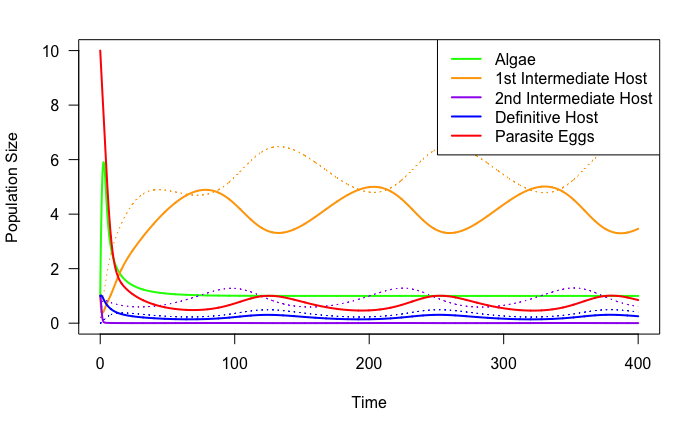

```r
lines(tset, P.simu, type = 'l', las = 1, lwd = 2, col = Pcol)
legend("topright",legend=c('Algae', '1st Intermediate Host','2nd Intermediate Host','Definitive Host', 'Parasite Eggs'),lwd=2,col=c(Acol, Fcol,Scol,Dcol,Pcol))
```